## Introduction

Understanding the factors that influence purchase frequency is crucial for businesses aiming to enhance customer engagement and optimize marketing strategies. Amidst shifting consumer preferences and the expanding influence of targeted marketing strategies, gaining insights into customer profiles across different regions and demographic groups is increasingly vital. In this project we aim to explore and analyze customer characteristics, and behavioral aspects. We will be examining the influence of various demographic and behavioral indicators and their effects on purchasing decisions. These indicators are crucial for comprehending the dynamics of consumer engagement, reflecting broader market trends and influencing business strategies.By preforming such analysis, companies can tailor their marketing efforts more effectively, potentially increasing customer loyalty and sales.

###Literture review

1. The Influence of Demographic Factors on Consumer Buying Behavior This study examined how age, gender, education, and income influence consumer buying behavior in the context of online shopping in Manado, Indonesia. The research utilized multiple linear regression analysis and found that age and education significantly impacted consumer behavior, while gender and income had less clear effects. The study highlighted the complex interplay of these demographic factors in shaping online consumer behavior.
2. Demographic Impacts on Environmentally Friendly Purchase Behaviors Fisher et al.’s research focused on how demographics influence environmentally friendly purchasing behaviors. They found that gender (particularly females) exhibited more green behaviors. This study is significant as it used specific behaviors rather than general attitudes to better gauge demographic impacts on environmental purchasing, suggesting that specific behavioral analysis may reveal more about the influence of demographics than previously understood.
3. Age, Gender, and Income: Do They Really Moderate Online Shopping Behavior? The study by Hernández et al. explored whether age, gender, and income moderate online shopping behavior among experienced e-shoppers. Interestingly, their findings suggest that these socioeconomic characteristics do not significantly influence the behavior of experienced online shoppers, indicating a homogenization of behavior across demographics in the digital shopping environmen(Emerald).

## Summary of dataset

This dataset captures the detailes of customer demographics and purchasing behaviors. It includes both fundamental personal attributes such as age, gender, income, education and behavioral data such as region, loyalty status, purchase frequency, purchase amount, product category, promotion usage, satisfaction score which are useful for understanding customer profiles and shopping patterns. we believe that these insights can aid in developing targeted marketing strategies, enhancing customer relationship management, and optimizing product offerings across various regions and demographic groups.The dataset contains 100,000 entries with 12 columns, detailing various aspects of customer data. Here is s a brief overview of each column:

```r
data <- read.csv("customer_data.csv")

print(str(data))
```

```
## 'data.frame':    100000 obs. of  12 variables:
##  $ id                : int  1 2 3 4 5 6 7 8 9 10 ...
##  $ age               : int  27 29 37 30 31 38 32 24 27 28 ...
##  $ gender            : chr  "Male" "Male" "Male" "Male" ...
##  $ income            : int  40682 15317 38849 11568 46952 7347 8265 47773 19154 24666 ...
##  $ education         : chr  "Bachelor" "Masters" "Bachelor" "HighSchool" ...
##  $ region            : chr  "East" "West" "West" "South" ...
##  $ loyalty_status    : chr  "Gold" "Regular" "Silver" "Regular" ...
##  $ purchase_frequency: chr  "frequent" "rare" "rare" "frequent" ...
##  $ purchase_amount   : int  18249 4557 11822 4098 19685 2822 3293 21794 5819 8779 ...
##  $ product_category  : chr  "Books" "Clothing" "Clothing" "Food" ...
##  $ promotion_usage   : int  0 1 0 0 1 0 0 0 0 0 ...
##  $ satisfaction_score: int  6 6 6 7 5 5 7 5 5 6 ...
## NULL
```

```r
summary(data)
```

```
##        id              age        gender              income
##  Min.   :     1   Min.   :12   Length:100000      Min.   : 5000
##  1st Qu.: 25001   1st Qu.:27   Class :character   1st Qu.:16272
##  Median : 50000   Median :30   Mode  :character   Median :27584
##  Mean   : 50000   Mean   :30                      Mean   :27516
##  3rd Qu.: 75000   3rd Qu.:33                      3rd Qu.:38747
##  Max.   :100000   Max.   :49                      Max.   :50000
##   education            region          loyalty_status     purchase_frequency
##  Length:100000      Length:100000      Length:100000      Length:100000
##  Class :character   Class :character   Class :character   Class :character
##  Mode  :character   Mode  :character   Mode  :character   Mode  :character
##
##
##
##  purchase_amount product_category   promotion_usage satisfaction_score
##  Min.   : 1118   Length:100000      Min.   :0.000   Min.   : 0.00
##  1st Qu.: 5583   Class :character   1st Qu.:0.000   1st Qu.: 4.00
##  Median : 9452   Mode  :character   Median :0.000   Median : 5.00
##  Mean   : 9635                      Mean   :0.301   Mean   : 5.01
##  3rd Qu.:13350                      3rd Qu.:1.000   3rd Qu.: 6.00
##  Max.   :26204                      Max.   :1.000   Max.   :10.00
```

### Limitations

The dataset we have used provides a comprehensive view of customer demographics and purchasing habits, serving as a robust base for understanding customer behaviors and market opportunities. However, like all datasets, it has its own limitations, and there are areas where additional information could enhance the quality of the dataset. For example, the dataset could benefit from incorporating time series data, which would allow for analysis of trends over time, seasonal buying patterns, or the timing of purchases relative to marketing campaigns. Features such as more detailed geographic data could also improve the accuracy of regional analysis, aiding in more localized marketing strategies. Furthermore, additional data on customer interactions, like customer service contacts or online engagement metrics, could offer deeper insights into customer satisfaction and loyalty. The inclusion of broader economic indicators or competitor data could also provide a more comprehensive context for the observed customer behaviors.

## EXPLORATORY DATA ANALYSIS (EDA)

## WHAT CAN WE DO WITH THE ANALYSIS?

**CONCEPTUAL FRAMEWORK**

## SMART QUESTIONS

### Analyze and Preprocess The Data Again

We preprocess the Data one more again to fit the models that we are going to test

```r
# Read the dataset
data <- read.csv("customer_data.csv")

# Display the first few rows of the dataset
head(data)
```

```
##   id age gender income  education region loyalty_status purchase_frequency
## 1  1  27   Male  40682   Bachelor   East           Gold           frequent
## 2  2  29   Male  15317    Masters   West        Regular               rare
## 3  3  37   Male  38849   Bachelor   West         Silver               rare
## 4  4  30   Male  11568 HighSchool  South        Regular           frequent
## 5  5  31 Female  46952    College  North        Regular         occasional
## 6  6  38   Male   7347   Bachelor  South         Silver         occasional
##   purchase_amount product_category promotion_usage satisfaction_score
## 1           18249            Books               0                  6
## 2            4557         Clothing               1                  6
## 3           11822         Clothing               0                  6
## 4            4098             Food               0                  7
## 5           19685         Clothing               1                  5
## 6            2822      Electronics               0                  5
```

```r
# Get a summary of each column in the dataset
summary(data)
```

```
##        id              age        gender              income
##  Min.   :     1   Min.   :12   Length:100000      Min.   : 5000
##  1st Qu.: 25001   1st Qu.:27   Class :character   1st Qu.:16272
##  Median : 50000   Median :30   Mode  :character   Median :27584
##  Mean   : 50000   Mean   :30                      Mean   :27516
##  3rd Qu.: 75000   3rd Qu.:33                      3rd Qu.:38747
##  Max.   :100000   Max.   :49                      Max.   :50000
##   education            region          loyalty_status     purchase_frequency
##  Length:100000      Length:100000      Length:100000      Length:100000
##  Class :character   Class :character   Class :character   Class :character
##  Mode  :character   Mode  :character   Mode  :character   Mode  :character
##
##
##
##  purchase_amount product_category   promotion_usage satisfaction_score
##  Min.   : 1118   Length:100000      Min.   :0.000   Min.   : 0.00
##  1st Qu.: 5583   Class :character   1st Qu.:0.000   1st Qu.: 4.00
##  Median : 9452   Mode  :character   Median :0.000   Median : 5.00
##  Mean   : 9635                      Mean   :0.301   Mean   : 5.01
##  3rd Qu.:13350                      3rd Qu.:1.000   3rd Qu.: 6.00
##  Max.   :26204                      Max.   :1.000   Max.   :10.00
```

```r
# Inspect the structure of the dataset
str(data)
```

```
## 'data.frame':    100000 obs. of  12 variables:
##  $ id                : int  1 2 3 4 5 6 7 8 9 10 ...
##  $ age               : int  27 29 37 30 31 38 32 24 27 28 ...
##  $ gender            : chr  "Male" "Male" "Male" "Male" ...
##  $ income            : int  40682 15317 38849 11568 46952 7347 8265 47773 19154 24666 ...
##  $ education         : chr  "Bachelor" "Masters" "Bachelor" "HighSchool" ...
##  $ region            : chr  "East" "West" "West" "South" ...
##  $ loyalty_status    : chr  "Gold" "Regular" "Silver" "Regular" ...
##  $ purchase_frequency: chr  "frequent" "rare" "rare" "frequent" ...
##  $ purchase_amount   : int  18249 4557 11822 4098 19685 2822 3293 21794 5819 8779 ...
##  $ product_category  : chr  "Books" "Clothing" "Clothing" "Food" ...
##  $ promotion_usage   : int  0 1 0 0 1 0 0 0 0 0 ...
##  $ satisfaction_score: int  6 6 6 7 5 5 7 5 5 6 ...
```

```r
# Check for missing values in each column
sapply(data, function(x) sum(is.na(x)))
```

```
##                 id                age             gender             income
##                  0                  0                  0                  0
##          education             region     loyalty_status purchase_frequency
##                  0                  0                  0                  0
##    purchase_amount   product_category    promotion_usage satisfaction_score
##                  0                  0                  0                  0
```

**Inspct for Outliers**

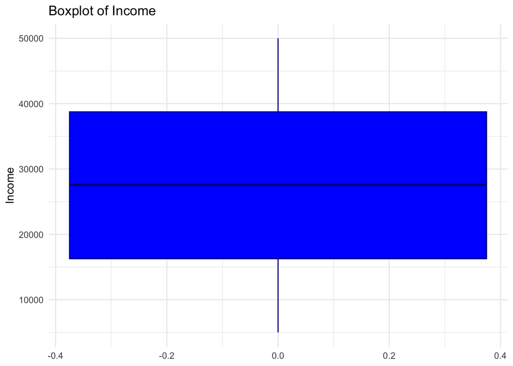

```r
# Load necessary library
library(ggplot2)

# Plotting boxplot for income
ggplot(data, aes(y = income)) +
  geom_boxplot(fill = "blue", color = "darkblue") +
  labs(title = "Boxplot of Income", y = "Income") +
  theme_minimal()
```

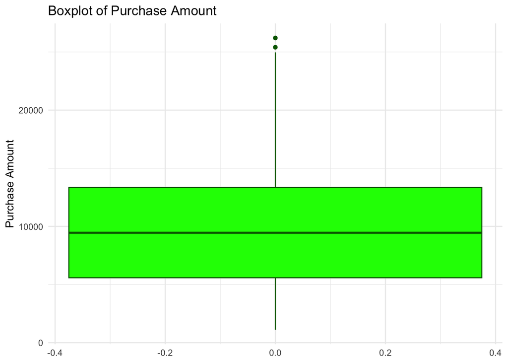

```r
# Plotting boxplot for purchase_amount
ggplot(data, aes(y = purchase_amount)) +
  geom_boxplot(fill = "green", color = "darkgreen") +
  labs(title = "Boxplot of Purchase Amount", y = "Purchase Amount") +
  theme_minimal()
```

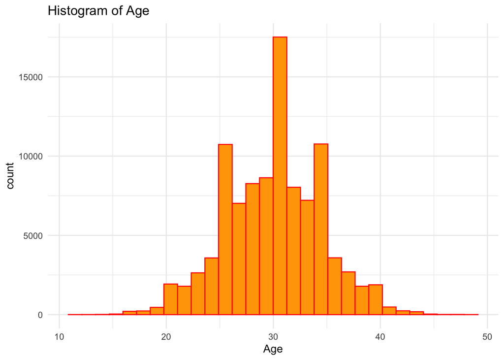

```r
# Plotting histogram for age
ggplot(data, aes(x = age)) +
  geom_histogram(bins = 30, fill = "orange", color = "red") +
  labs(title = "Histogram of Age", x = "Age") +
  theme_minimal()
```

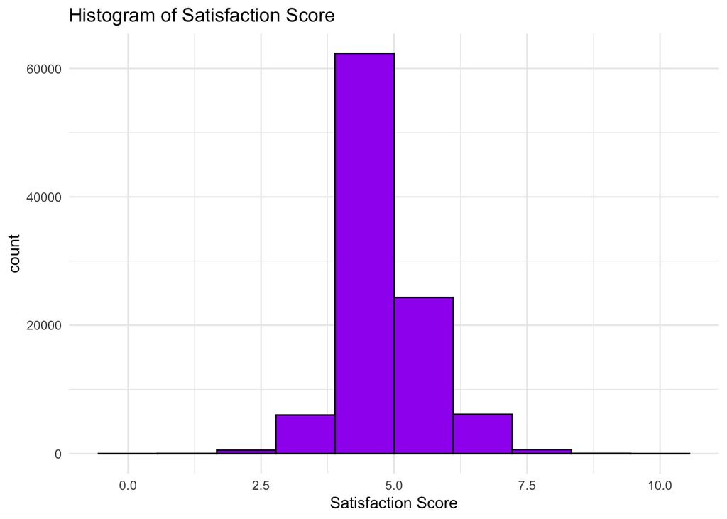

```r
# Plotting histogram for satisfaction_score
ggplot(data, aes(x = satisfaction_score)) +
  geom_histogram(bins = 10, fill = "purple", color = "black") +
  labs(title = "Histogram of Satisfaction Score", x = "Satisfaction Score") +
  theme_minimal()
```

**Boxplot of Income:** The income distribution seems to have no visible outliers, and all data points fall within a reasonable range.

**Boxplot of Purchase Amount:** There are a few outliers present above the upper whisker. These are values that lie beyond 1.5 times the interquartile range above the third quartile. You might want to investigate these points further to determine if they are errors or just natural variations in the data. Depending on the business context, very high purchase amounts might be legitimate.

**Histogram of Age:** The age distribution appears to be fairly normal, centered around the late 20s to early 30s. There are no apparent outliers here.

**Convert to factors:**

```r
# Convert character columns to factors
data$gender <- as.factor(data$gender)
data$education <- as.factor(data$education)
data$region <- as.factor(data$region)
data$loyalty_status <- as.factor(data$loyalty_status)
data$purchase_frequency <- as.factor(data$purchase_frequency)
data$product_category <- as.factor(data$product_category)

# Check the updated structure of the dataset to confirm changes
str(data)
```

```
## 'data.frame':    100000 obs. of  12 variables:
##  $ id                : int  1 2 3 4 5 6 7 8 9 10 ...
##  $ age               : int  27 29 37 30 31 38 32 24 27 28 ...
##  $ gender            : Factor w/ 2 levels "Female","Male": 2 2 2 2 1 2 1 1 2 1 ...
##  $ income            : int  40682 15317 38849 11568 46952 7347 8265 47773 19154 24666 ...
##  $ education         : Factor w/ 4 levels "Bachelor","College",..: 1 4 1 3 2 1 1 3 2 3 ...
##  $ region            : Factor w/ 4 levels "East","North",..: 1 4 4 3 2 3 3 2 1 2 ...
##  $ loyalty_status    : Factor w/ 3 levels "Gold","Regular",..: 1 2 3 2 2 3 3 2 2 2 ...
##  $ purchase_frequency: Factor w/ 3 levels "frequent","occasional",..: 1 3 3 1 2 2 1 3 2 3 ...
##  $ purchase_amount   : int  18249 4557 11822 4098 19685 2822 3293 21794 5819 8779 ...
##  $ product_category  : Factor w/ 7 levels "Beauty","Books",..: 2 3 3 5 3 4 3 2 3 5 ...
##  $ promotion_usage   : int  0 1 0 0 1 0 0 0 0 0 ...
##  $ satisfaction_score: int  6 6 6 7 5 5 7 5 5 6 ...
```

```r
# Load randomForest package
library(randomForest)

# Ensure 'purchase_frequency' is a factor, if not already
data$purchase_frequency <- as.factor(data$purchase_frequency)

# Fit Random Forest to predict purchase frequency based solely on income
# We'll use a basic model with default settings for demonstration purposes
rf_model_income <- randomForest(purchase_frequency ~ income, data = data, ntree = 100, importance = TRUE)

# Obtain the importance of the 'income' variable
income_importance <- importance(rf_model_income)

# Print the importance
print(income_importance)
```

```
##        frequent occasional  rare MeanDecreaseAccuracy MeanDecreaseGini
## income    0.178       2.28 -3.05               -0.425            35483
```

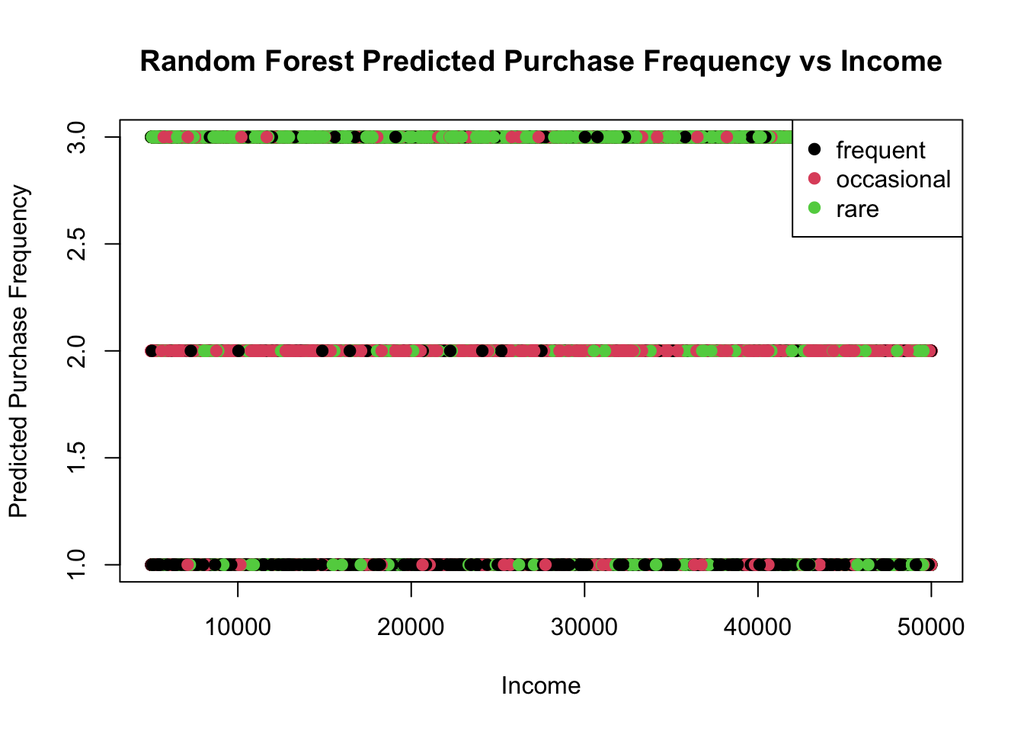

```r
# We can also look at a simple plot of the model's predicted values vs the income to visualize the relationship
predicted_frequency <- predict(rf_model_income, data)
plot(data$income, predicted_frequency, col = data$purchase_frequency, pch = 19,
     main = "Random Forest Predicted Purchase Frequency vs Income",
     xlab = "Income", ylab = "Predicted Purchase Frequency")
legend("topright", legend = levels(data$purchase_frequency), col = 1:length(levels(data$purchase_frequency)), pch = 19)
```

```r
# Since the purchase frequency is categorical, we could alternatively use the model to predict the probability of each class
predicted_probs <- predict(rf_model_income, data, type = "prob")
```

**Feature Importance:** The ‘MeanDecreaseAccuracy’ and ‘MeanDecreaseGini’ are measures of feature importance. They indicate how much each predictor (in this case, ‘income’) contributes to the accuracy of the model and the purity of the model’s nodes.

**MeanDecreaseAccuracy:** A negative value suggests that including the ‘income’ variable in the model does not contribute to an increase in the accuracy of the model. In fact, it may be slightly decreasing it. However, since the decrease is relatively small, it’s possible that ‘income’ just isn’t a strong predictor in the presence of other variables. **MeanDecreaseGini:** The high Gini decrease value for ‘income’ suggests that it’s an important variable for creating distinct groups or nodes within the Random Forest. A higher Gini decrease generally indicates a higher importance in the context of the model’s internal decision-making process.

**Plot Interpretation:** The plot shows the predicted purchase frequency as a function of ‘income’. Each dot represents a prediction for a customer, and the colors represent the different levels of purchase frequency (green for ‘rare’, pink for ‘occasional’, black for ‘frequent’).

From the plot, we can observe the following:

There does not appear to be a clear trend that would indicate higher income leads to a specific purchase frequency category. The predictions for ‘rare’, ‘occasional’, and ‘frequent’ are somewhat evenly spread across different incomes.

### Q2: How does customer satisfaction score influence the frequency of purchases in the dataset?

Given that ‘purchase_frequency’ is a categorical variable and ‘satisfaction_score’ is numerical, we can use machine learning classification algorithms to predict ‘purchase_frequency’ based on ‘satisfaction_score’. We can then analyze the results to understand the influence of satisfaction scores on purchase frequency.

Let’s use a Random Forest classifier for this task, as it can handle both categorical and numerical data and can provide insights into feature importance.

```r
# Load randomForest package
library(randomForest)

# Fit Random Forest to predict purchase frequency based on satisfaction_score
rf_model_satisfaction <- randomForest(purchase_frequency ~ satisfaction_score, data = data, ntree = 100, importance = TRUE)

# Obtain the importance of the 'satisfaction_score' variable
satisfaction_importance <- importance(rf_model_satisfaction)

# Print the importance
print(satisfaction_importance)
```

```
##                    frequent occasional rare MeanDecreaseAccuracy
## satisfaction_score    0.829      -1.01 1.81                0.889
##                    MeanDecreaseGini
## satisfaction_score             12.6
```

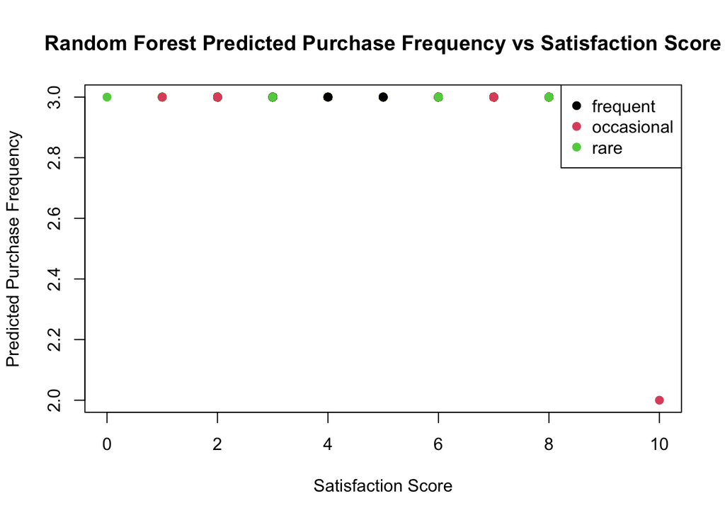

```r
# We can also visualize the relationship between satisfaction score and predicted purchase frequency
predicted_frequency <- predict(rf_model_satisfaction, data)
plot(data$satisfaction_score, predicted_frequency, col = data$purchase_frequency, pch = 19,
     main = "Random Forest Predicted Purchase Frequency vs Satisfaction Score",
     xlab = "Satisfaction Score", ylab = "Predicted Purchase Frequency")
legend("topright", legend = levels(data$purchase_frequency), col = 1:length(levels(data$purchase_frequency)), pch = 19)
```

```r
# Optionally, we can calculate the probability of each purchase frequency class
predicted_probs <- predict(rf_model_satisfaction, data, type = "prob")
```

**Logistic Regression**

```r
# Load nnet for multinomial logistic regression
library(nnet)

# Fit Multinomial Logistic Regression on the data
multinom_model <- multinom(purchase_frequency ~ satisfaction_score, data = data)
```

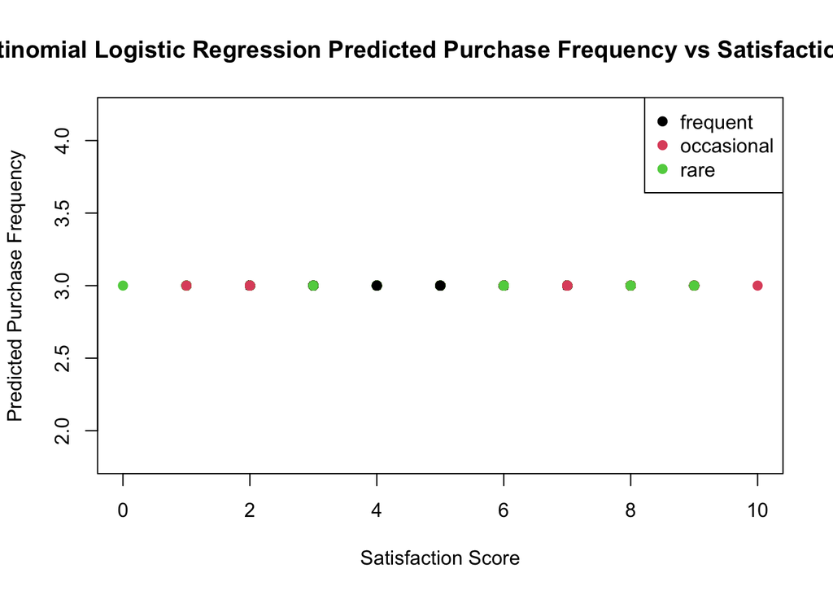

```r
# Predict on the data using the Multinomial Logistic Regression model
multinom_predictions <- predict(multinom_model, data)

# Visualize the relationship
plot(data$satisfaction_score, as.numeric(multinom_predictions), col = as.numeric(data$purchase_frequency), pch = 19,
     main = "Multinomial Logistic Regression Predicted Purchase Frequency vs Satisfaction Score",
     xlab = "Satisfaction Score", ylab = "Predicted Purchase Frequency")
legend("topright", legend = levels(data$purchase_frequency), pch = 19, col = 1:length(levels(data$purchase_frequency)))
```

**k-NN**

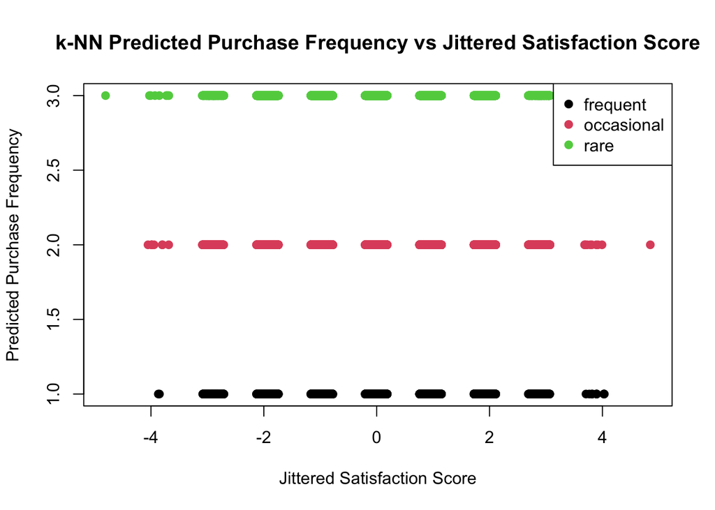

```r
library(class)
data$satisfaction_score_scaled <- scale(data$satisfaction_score)
# Add jitter to the satisfaction scores to introduce small variances
data$satisfaction_score_jittered <- jitter(data$satisfaction_score_scaled)

# Fit k-NN using the jittered data
set.seed(123) # Set seed for reproducibility
knn_predictions <- knn(train = data[, 'satisfaction_score_jittered', drop = FALSE],
                       test = data[, 'satisfaction_score_jittered', drop = FALSE],
                       cl = data$purchase_frequency, k = 1)

# Visualize the relationship
plot(data$satisfaction_score_jittered, as.numeric(knn_predictions), col = as.numeric(data$purchase_frequency), pch = 19,
     main = "k-NN Predicted Purchase Frequency vs Jittered Satisfaction Score",
     xlab = "Jittered Satisfaction Score", ylab = "Predicted Purchase Frequency")
legend("topright", levels(data$purchase_frequency), pch = 19, col = 1:length(levels(data$purchase_frequency)))
```

Looking at the output and plots for the three different models—multinomial logistic regression, k-NN with jittering, and random forest—we can draw some conclusions about the relationship between customer satisfaction score and purchase frequency.

**Multinomial Logistic Regression Plot Interpretation:** The plot shows discrete points because logistic regression estimates probabilities that translate into specific classes. The points represent predicted purchase frequencies at different satisfaction scores.

**k-NN Plot Interpretation:** The k-NN plot, with jittering added to the satisfaction scores, shows a clear separation of classes.

**Random Forest Plot Interpretation:** The Random Forest plot also displays predictions for purchase frequency at different satisfaction scores.

- Similar to the multinomial logistic regression model, the random forest predictions do not show a clear trend of satisfaction scores leading to a particular purchase frequency.
- The random forest seems to have a bit of a mix in its predictions across satisfaction scores for different purchase frequencies.

**Feature Importance from Random Forest:** - The ‘MeanDecreaseAccuracy’ value for ‘satisfaction_score’ is positive, indicating that the satisfaction score has a contribution to improving model accuracy.

- The ‘MeanDecreaseGini’ also shows a positive value, suggesting that the satisfaction score helps in splitting the data into pure nodes effectively within the Random Forest model.

**Overall Conclusion:** - The satisfaction score has some influence on purchase frequency, as indicated by its positive MeanDecreaseAccuracy and MeanDecreaseGini values in the random forest model.

### Q3: Can we segment customers effectively based on their purchasing behavior and demographic factors by the next marketing cycle?

- answerin this question can be done by using clustering techniques like K-means clustering.First, we will start by performing the Elbow Method to detrmine the optimal number of clusters we need to answer this question.

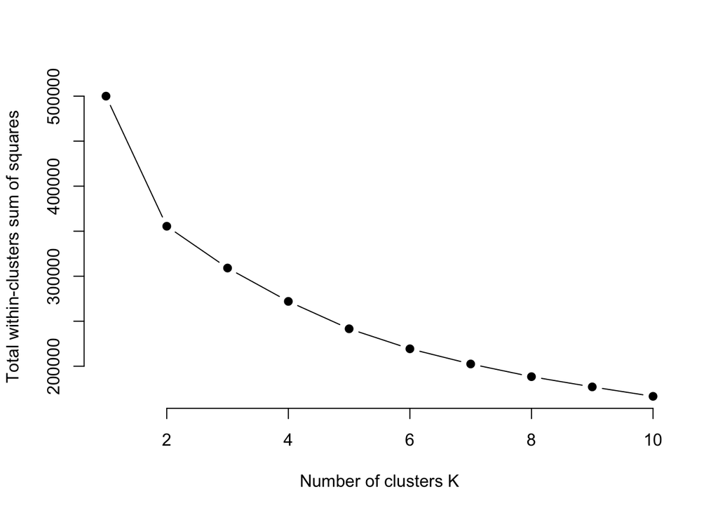

```r
library(dplyr)
library(ggplot2)
library(factoextra)

data <- data %>%
  mutate_if(is.character, as.factor) %>%  # Convert characters to factors
  mutate_if(is.factor, as.numeric)

data_for_clustering <- data %>%
  select(age, income, region, purchase_amount, purchase_frequency) %>%
  na.omit() %>%  # Removing any NAs
  scale()

set.seed(123)
wss <- sapply(1:10, function(k) {
  kmeans(data_for_clustering, k, nstart = 10)$tot.withinss
})
plot(1:10, wss, type = "b", pch = 19, frame = FALSE,
     xlab = "Number of clusters K",
     ylab = "Total within-clusters sum of squares")
```

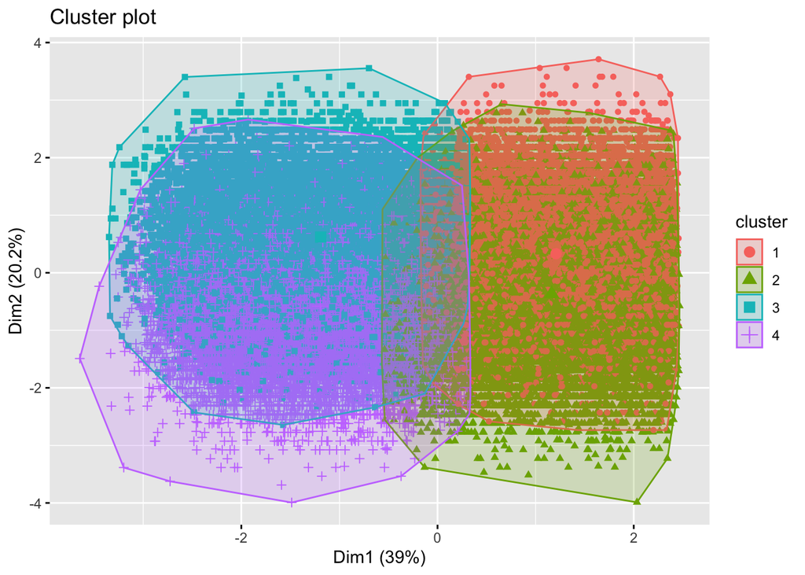

```r
# Load necessary libraries
if (!require("dplyr")) install.packages("dplyr")
if (!require("ggplot2")) install.packages("ggplot2")
if (!require("factoextra")) install.packages("factoextra")

library(dplyr)
library(ggplot2)
library(factoextra)

# Manually convert factor columns to numeric if appropriate
data <- data %>%
  mutate_if(is.factor, as.character) %>%  # Convert all factors to characters first
  mutate(
    region = as.numeric(as.factor(region)),           # Convert 'region' to numeric
    purchase_frequency = as.numeric(as.factor(purchase_frequency))  # Convert 'purchase_frequency' to numeric
  )

# You can add similar lines for other factor columns needing conversion

# Ensure all necessary columns are numeric
if (any(!sapply(data[c("age", "income", "region", "purchase_amount", "purchase_frequency")], is.numeric))) {
  stop("Not all columns are numeric. Check factor to numeric conversion.")
}

# Selecting relevant features for clustering
data_for_clustering <- data %>%
  select(age, income, region, purchase_amount, purchase_frequency) %>%
  na.omit() %>%  # Removing any NAs
  scale()  # Standardizing the data

# Perform K-means clustering
set.seed(123)  # Setting seed for reproducibility
k <- 4  # Number of clusters
clusters <- kmeans(data_for_clustering, centers = k, nstart = 25)

# Adding cluster results to the original data
data$cluster <- as.factor(clusters$cluster)

# Plotting clusters, here using PCA for dimensionality reduction to visualize in 2D
fviz_cluster(clusters, data = data_for_clustering, geom = "point")
```

```r
# Assuming you have the clusters and the data already prepared
# Adding the cluster assignments to your original data
data$cluster <- as.factor(clusters$cluster)

# Profiling each cluster by calculating summary statistics for the features
cluster_profiles <- data %>%
  group_by(cluster) %>%
  summarise(across(everything(), list(mean = mean, sd = sd))) # change 'everything()' if you have non-numeric columns

# View the cluster profiles
print(cluster_profiles)
```

```
## # A tibble: 4 × 29
##   cluster id_mean  id_sd age_mean age_sd gender_mean gender_sd income_mean
##   <fct>     <dbl>  <dbl>    <dbl>  <dbl>       <dbl>     <dbl>       <dbl>
## 1 1        49809. 28934.     30.0   4.48        1.50     0.500      16283.
## 2 2        50318. 28837.     30.0   4.47        1.50     0.500      16697.
## 3 3        50006. 28818.     29.9   4.49        1.50     0.500      38581.
## 4 4        49863. 28881.     30.0   4.48        1.50     0.500      38630.
## # ℹ 21 more variables: income_sd <dbl>, education_mean <dbl>,
## #   education_sd <dbl>, region_mean <dbl>, region_sd <dbl>,
## #   loyalty_status_mean <dbl>, loyalty_status_sd <dbl>,
## #   purchase_frequency_mean <dbl>, purchase_frequency_sd <dbl>,
## #   purchase_amount_mean <dbl>, purchase_amount_sd <dbl>,
## #   product_category_mean <dbl>, product_category_sd <dbl>,
## #   promotion_usage_mean <dbl>, promotion_usage_sd <dbl>, …
```

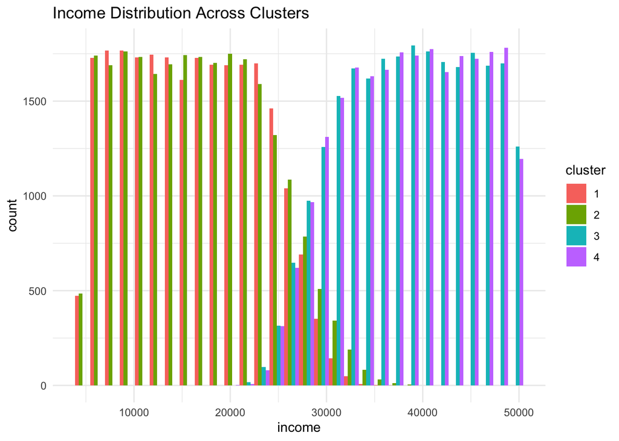

```r
# You can also visualize the distribution of each feature within each cluster
# For example, plotting the distribution of income across clusters
ggplot(data, aes(x = income, fill = cluster)) +
  geom_histogram(position = "dodge") +
  theme_minimal() +
  labs(title = "Income Distribution Across Clusters")
```

```r
library(dplyr)

# Assuming 'data' is your data frame and it contains a 'cluster' column from K-means
cluster_averages <- data %>%
  group_by(cluster) %>%
  summarise(average_income = mean(income, na.rm = TRUE))  # Calculate average income for each cluster

print(cluster_averages)
```

```
## # A tibble: 4 × 2
##   cluster average_income
##   <fct>            <dbl>
## 1 1               16283.
## 2 2               16697.
## 3 3               38581.
## 4 4               38630.
```

###References:

• Rambi, F. M., Saerang, D. P. E., & Rumokoy, F. S. (2014). The influence of demographic factors (age, gender, education, and income) on consumer buying behavior. Journal EMBA, 2(1), 90-98.

• Fisher, C., Bashyal, S., & Bachman, B. (2012). Demographic impacts on environmentally friendly purchase behaviors. Journal of Targeting, Measurement and Analysis for Marketing, 20(3/4), 172-184. https://doi.org/10.1057/jt.2012.13

• Hernández, B., Jiménez, J., & Martín, M. J. (2011). Age, gender, and income: Do they really moderate online shopping behavior? Online Information Review, 35(1), 113-133. https://doi.org/10.1108/14684521111113614